# Empirical Research in Economics - Exercise 2

Student1 Tobias Lind Knudsen, Student1 Nr. 21-621-636

Student2 Alexandra Gort, Student2 Nr. 20-617-908

Student3 Olivier Benoit, Student3 Nr. 20-612-057

2023-02-05

# Part 0: Load packages and data set

```r
# import packages
library(dplyr)
library(ggplot2)
# import data set and save it in the environment
# Loading the data into the environment
load("C:/Users/tobia/Desktop/Data/BWGHT.RData")
```

# Part I

Usually one tries to get an idea about the data set before estimating any regression. Answer the following questions about this.

**(i) Birth weight is in “Ounces”. Convert the weight from ounces to kilograms.**

```r
# HERE: CONVERT YOUR VARIABLE
# Creating a column containing the weights converted into kg.
data$bwght_kg <- data$bwght * 0.02834952

# Changing the attribute, so it fits the new column.
attr(data$bwght_kg, "label") <- "birth weight, kg"

head(data)
```

```
## # A tibble: 6 × 15
##   faminc cigtax cigprice bwght fatheduc motheduc parity  male white  cigs lbwght
##    <dbl>  <dbl>    <dbl> <dbl>    <dbl>    <dbl>  <dbl> <dbl> <dbl> <dbl>  <dbl>
## 1   13.5   16.5     122.   109       12       12      1     1     1     0   4.69
## 2    7.5   16.5     122.   133        6       12      2     1     0     0   4.89
## 3    0.5   16.5     122.   129       -1       12      2     0     0     0   4.86
## 4   15.5   16.5     122.   126       12       12      2     1     0     0   4.84
## 5   27.5   16.5     122.   134       14       12      2     1     1     0   4.90
## 6    7.5   16.5     122.   118       12       14      6     1     0     0   4.77
## # … with 4 more variables: bwghtlbs <dbl>, packs <dbl>, lfaminc <dbl>,
## #   bwght_kg <dbl>
```

**(ii) Graph and comment on the distribution of birth weight and maternal education.**

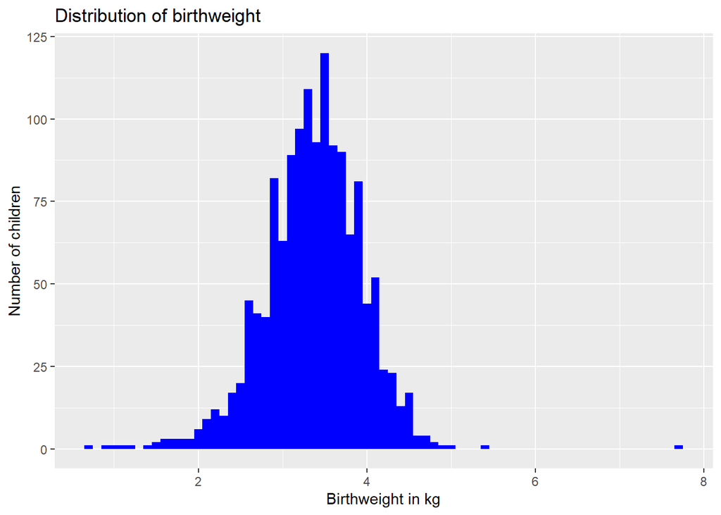

```r
# HERE: create your graph with ggplot
# Creating a histogram from ggplot2 and labelling the axes.
ggplot(data, aes(bwght_kg)) +
  geom_histogram(binwidth = 0.1, fill = "blue") +
  labs(x = "Birthweight in kg",
       y = "Number of children",
       title = "Distribution of birthweight")
```

Here: write your comment.

The distribution of weights at birth very much resembles a normal distribution. We can however recognize that it is slightly left-skewed, there seem to be more cases of babies being lighter than average than babies being heavier than average. There are also a couple of outliers weighing significantly more than the average.

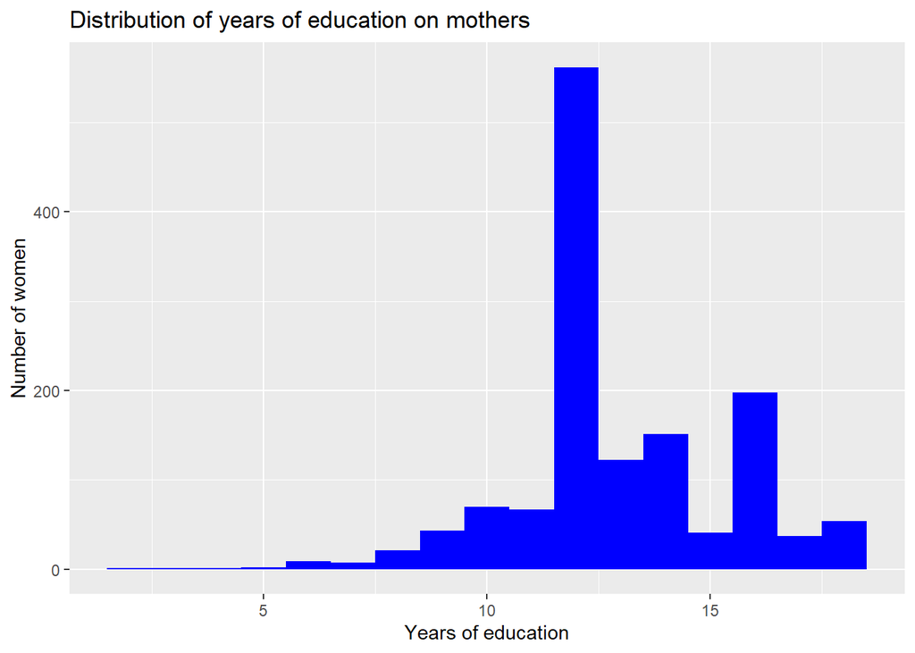

```r
# HERE: create your graph with ggplot
# Creating a histogram and labelling the axes.
ggplot(data, aes(motheduc)) +
  geom_histogram(binwidth = 1, fill = "blue") +
  labs(x = "Years of education",
       y = "Number of women",
       title = "Distribution of years of education on mothers")
```

Here: write your comment.

At the 12 years mark we see a strong increase in births, this is most probably due to the fact that 12 years was the common schooling time in the 1980s, while it is more around 14 years today.

**(iii) What is the average birth weight of infants whose mothers did not smoke cigarettes during pregnancy and that of infants whose mothers consumed a whole pack per day (A pack contains 20 cigarettes)? Compare the two averages and comment on any difference.**

```r
# Here: compute your code
# Calculating avg weight for non-smokers
# Using dplyr to create a new variable containing the average weight on the filtered data for non-smokers.
mean_bwght_nocig <- data %>%
  filter(cigs == 0) %>%
  summarize(avg_bwght = mean(bwght_kg))

cat("The birth weight of children, whose mothers were non-smokers is:", as.character(round(mean_bwght_nocig, 4)))
```

```
## The birth weight of children, whose mothers were non-smokers is: 3.4037
```

```r
# Using dplyr to create a new variable containing the average weight on the filtered data for one pack a day smokers.
mean_bwght_pack <- data %>%
  filter(packs == 1) %>%
  summarize(avg_bwght = mean(bwght_kg))

cat("The birth weight of children, whose mothers smoked one pack a day is:", as.character(round(mean_bwght_pack, 4)))
```

```
## The birth weight of children, whose mothers smoked one pack a day is: 3.1194
```

```r
# Calculating the difference between the averages and assigning it to a new variable.
dif <- mean_bwght_nocig - mean_bwght_pack

cat("The difference in average birth weight is:", as.character(round(dif, 4)))
```

```
## The difference in average birth weight is: 0.2843
```

Here: write your comment

The average weight at birth when no cigarettes have been smoken is around 3.4kg. When a pack a day is smoken it is 3.12kg. This shows that children that have smoking mothers are around 10% lighter at birth.

**(iv) Consider the values of the variable** $fatheduc$. A value of -1 represents “no response.” Code the variable accordingly. What problem may arise due to missing values?

```r
# Here: write your code
# Copying the data to a new variable and replacing all (-1) with NA, luckily only fatheduc column contains (-1)s.
new_data <- data

new_data[new_data == -1] <- NA

head(new_data)
```

```
## # A tibble: 6 × 15
##   faminc cigtax cigprice bwght fatheduc motheduc parity  male white  cigs lbwght
##    <dbl>  <dbl>    <dbl> <dbl>    <dbl>    <dbl>  <dbl> <dbl> <dbl> <dbl>  <dbl>
## 1   13.5   16.5     122.   109       12       12      1     1     1     0   4.69
## 2    7.5   16.5     122.   133        6       12      2     1     0     0   4.89
## 3    0.5   16.5     122.   129       NA       12      2     0     0     0   4.86
## 4   15.5   16.5     122.   126       12       12      2     1     0     0   4.84
## 5   27.5   16.5     122.   134       14       12      2     1     1     0   4.90
## 6    7.5   16.5     122.   118       12       14      6     1     0     0   4.77
## # … with 4 more variables: bwghtlbs <dbl>, packs <dbl>, lfaminc <dbl>,
## #   bwght_kg <dbl>
```

Here: write your comment

If we kept -1 as an observation, we would have a bar with around 200 fathers that have -1 year of education and this would not make any sense. It would skew the data in the wrong direction.